# Exercise

Kevin

2020/10/9

# 第三章 次數分配習題

### Ex3-3

The following table gives the 2002 median annual salaries of various categories of scientists in the United States holding PhDs. Construct a bar graph for these data with “Annual Salary” on the axis and “Category of Scientist” on the axis. Arrange the categories so that the salaries decrease from left to right.

| Category of Scientist | Annual Salary ($) |
| --- | --- |
| Biological and Health Sciences | 70,100 |
| Chemistry | 79,100 |
| Computer and Math Sciences | 75,000 |
| Psychology | 66,700 |
| Sociology and Anthropology | 63,100 |

https://media.cheggcdn.com/study/987/987f544f-8b95-433a-bde8-b040d801ad44/7780-3-3QPEI1.png

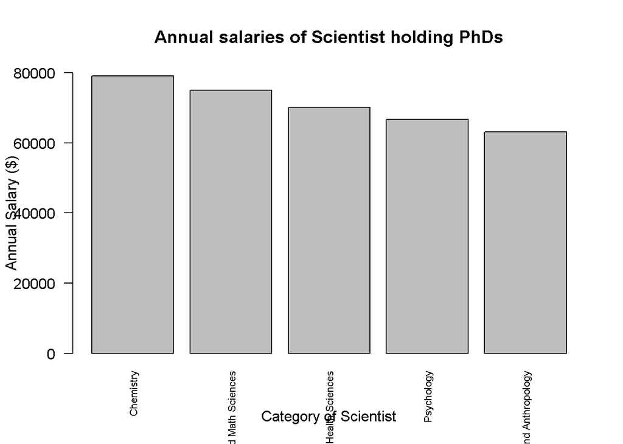

```r
Category <- c("Chemistry",
              "Computer and Math Sciences",
              "Biological and Health Sciences",
              "Psychology",
              "Sociology and Anthropology")

Salary <- c(79100,75000,70100,66700,63100)

barplot(Salary,
        ylim = c(0,80000),
        main = "Annual salaries of Scientist holding PhDs",
        xlab = "Category of Scientist",
        ylab = "Annual Salary ($)",
        names.arg = Category, # x軸標籤命名
        las=2,                # x軸標籤翻轉
        cex.names = 0.7)      # x軸標籤字體大小
```

### Ex3-5

The following scores were obtained by a college sophomore class on an English exam:

| 60 94 75 82 72 57 92 75 85 77 91 |
| --- |
| 72 85 64 78 75 62 49 70 94 72 84 |
| 55 90 88 81 64 91 79 66 68 67 74 |
| 45 76 73 68 85 73 83 85 71 87 57 |
| 82 78 68 70 71 78 69 98 65 61 83 |
| 84 69 77 81 87 79 64 72 55 76 68 |
| 93 56 67 71 83 72 82 78 62 82 49 |
| 63 73 89 78 81 93 72 76 73 90 76 |

1. Construct a frequency distribution of the ungrouped scores ( ).

```r
Score <- c(60,94,75,82,72,57,92,75,85,77,91,
72,85,64,78,75,62,49,70,94,72,84,
55,90,88,81,64,91,79,66,68,67,74,
45,76,73,68,85,73,83,85,71,87,57,
82,78,68,70,71,78,69,98,65,61,83,
84,69,77,81,87,79,64,72,55,76,68,
93,56,67,71,83,72,82,78,62,82,49,
63,73,89,78,81,93,72,76,73,90,76)

fd <- table(Score)
fd <- as.data.frame(fd,stringsAsFactors = F)
fd$Score <- as.numeric(fd$Score)
fd <- fd[order(fd$Score,decreasing = T),]
print(fd,row.names = FALSE)
```

```
##  Score Freq
##     98    1
##     94    2
##     93    2
##     92    1
##     91    2
##     90    2
##     89    1
##     88    1
##     87    2
##     85    4
##     84    2
##     83    3
##     82    4
##     81    3
```

[output cut: 25 more lines]

2. Construct a frequency distribution of grouped scores having approximately 15 intervals. List both the apparent and real limits of each interval.

```r
library(dplyr)
fd$class_interval <- cut(fd$Score,
                         breaks=15,           #分幾塊
                         dig.lab=T,           #取整數
                         ordered_result=T,    #有大小
                         include.lowest = T)  #含最小值
fd2 <- fd %>%
  group_by(class_interval) %>%
  summarise(f=sum(Freq))
fd2 <- fd2[order(fd2$class_interval,decreasing = T),]
knitr::kable(fd2)
```

| class_interval | f |
| --- | --- |
| (94,98] | 1 |
| (91,94] | 7 |
| (87,91] | 4 |
| (84,87] | 8 |
| (80,84] | 10 |
| (77,80] | 9 |
| (73,77] | 8 |
| (70,73] | 15 |
| (66,70] | 8 |
| (63,66] | 6 |
| (59,63] | 4 |
| (56,59] | 3 |
| (52,56] | 2 |
| (49,52] | 2 |
| [45,49] | 1 |

上面的組距不同，若要做組距相同的表如下

```r
range_fd <- range(fd$Score)
width <- round( diff(range_fd)/15 )
Complement <- width-(diff(range_fd) %% width)
breaks <- seq(range_fd[1]-0.5-Complement,
              range_fd[2]+0.5+width,
              by=width)
fd$class_interval2 <- cut(fd$Score,
                          breaks=breaks,
                          ordered_result=T,
                          right = T,
                          include.lowest = T)  #含最小值
fd3 <- fd$class_interval2 %>%
  table() %>%
  as.data.frame()
fd3[,3] <-
  paste0( head(ceiling(breaks),-1) ,
          "-",
          tail(floor(breaks),-1) )
fd3 <-fd3[,c(3,1,2)]
names(fd3) <- c("Class Interval","Real Limits","f")

fd3 <- fd3[order(fd3$`Class Interval`,decreasing = T),]
knitr::kable(fd3)
```

|  | Class Interval | Real Limits | f |
| --- | --- | --- | --- |
| 15 | 98-101 | (97.5,102] | 1 |
| 14 | 94-97 | (93.5,97.5] | 1 |
| 13 | 90-93 | (89.5,93.5] | 4 |
| 12 | 86-89 | (85.5,89.5] | 3 |
| 11 | 82-85 | (81.5,85.5] | 4 |
| 10 | 78-81 | (77.5,81.5] | 3 |
| 9 | 74-77 | (73.5,77.5] | 4 |
| 8 | 70-73 | (69.5,73.5] | 4 |
| 7 | 66-69 | (65.5,69.5] | 4 |
| 6 | 62-65 | (61.5,65.5] | 4 |
| 5 | 58-61 | (57.5,61.5] | 2 |
| 4 | 54-57 | (53.5,57.5] | 3 |
| 3 | 50-53 | (49.5,53.5] | 0 |
| 2 | 46-49 | (45.5,49.5] | 1 |
| 1 | 42-45 | [41.5,45.5] | 1 |

3. Construct a histogram of the frequency distribution constructed in part b.

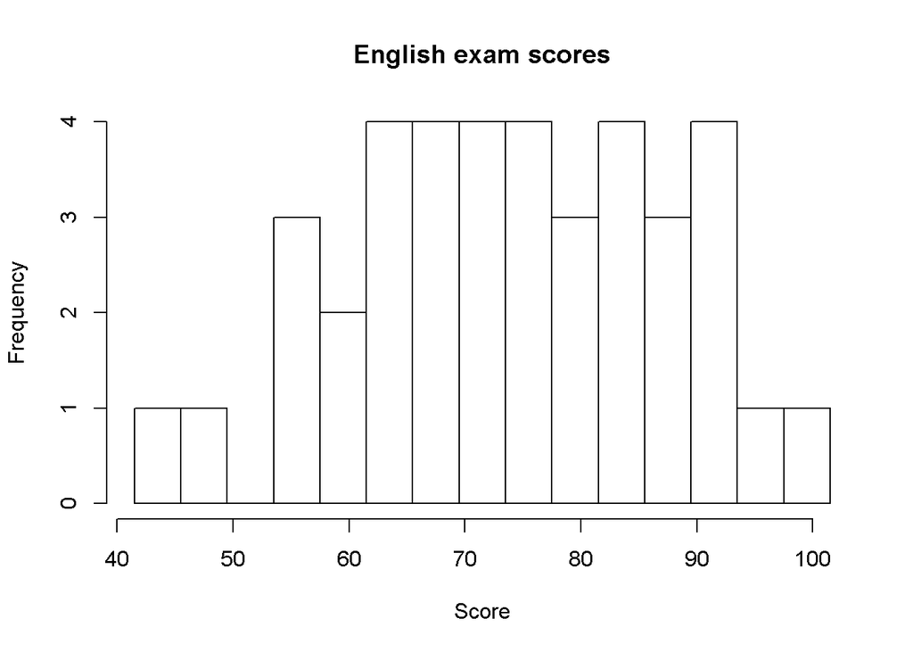

```r
hist(fd$Score,
     breaks=breaks,
     xlim=range(breaks),
     main = "English exam scores",
     xlab = "Score")
```

4. Is the distribution skewed or symmetrical? If it is skewed, is it skewed positively or negatively?

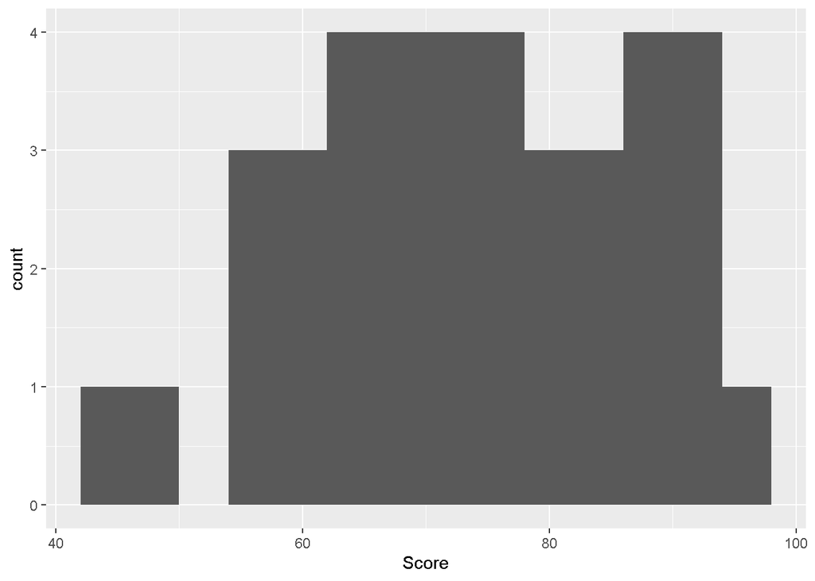

```r
library(ggplot2)
library(tidyverse)
ggplot(fd,aes(Score))+geom_histogram(binwidth=4)
```

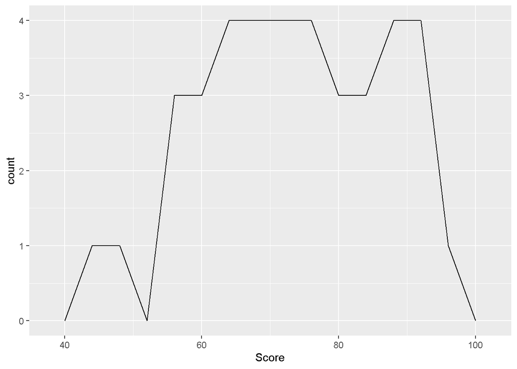

```r
ggplot(fd,aes(Score))+geom_freqpoly(binwidth=4)
```

看起來像 Negative skewed，但是不明顯，分多一點看看

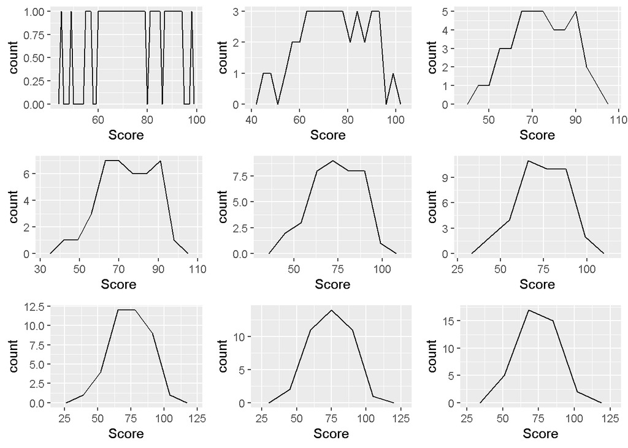

```r
plot_frequency <- function(x){
  ggplot(fd,aes(Score))+geom_freqpoly(binwidth=x)
}
all_plots <- map(seq(1,17,2), plot_frequency)
cowplot::plot_grid(plotlist = all_plots)
```

似乎 symmetrical 也可以。

5. Construct a stem and leaf diagram with the last digit being a leaf and the first digit a stem. Repeat stem values twice.

```r
stem(fd$Score,1)
```

```
##
##   The decimal point is 1 digit(s) to the right of the |
##
##   4 | 59
##   5 | 567
##   6 | 0123456789
##   7 | 0123456789
##   8 | 12345789
##   9 | 012348
```

```r
stem(fd$Score,2)
```

```
##
##   The decimal point is 1 digit(s) to the right of the |
##
##   4 | 59
##   5 |
##   5 | 567
##   6 | 01234
##   6 | 56789
##   7 | 01234
##   7 | 56789
##   8 | 1234
##   8 | 5789
##   9 | 01234
##   9 | 8
```

6. Which diagram do you like better, the histogram of part c or the stem and leaf diagram of part e? Explain.

看目的和資料數，資料大 histogram 較方便

## Ex3-10

The following scores show the amount of weight lost (in pounds) by each client of a weight control clinic during the last year:

| 10 13 22 26 16 23 35 53 17 32 |
| --- |
| 41 35 24 23 27 16 20 60 48 43 |
| 52 31 17 20 33 18 23 8 24 15 |
| 26 46 30 19 22 13 22 14 21 39 |
| 28 43 37 15 20 11 25 9 15 21 |
| 21 25 34 10 23 29 28 18 17 24 |
| 16 26 7 12 28 20 36 16 14 |
| 18 16 57 31 34 28 42 19 26 |

1. Construct a frequency distribution of grouped scores with approximately 10 intervals.

```r
lost  <- c(10,13,22,26,16,23,35,53,17,32,
41,35,24,23,27,16,20,60,48,43,
52,31,17,20,33,18,23,8,24,15,
26,46,30,19,22,13,22,14,21,39,
28,43,37,15,20,11,25,9,15,21,
21,25,34,10,23,29,28,18,17,24,
16,26,7,12,28,20,36,16,14,
18,16,57,31,34,28,42,19,26)

range_lost <- range(lost)
width <- round( diff(range_lost)/10 )
Complement <- width-(diff(range_fd) %% width)
breaks <- seq(range_lost[1]-0.5-Complement,
              range_lost[2]+0.5+width,
              by=width)
class_interval <- cut(lost,
                      breaks=breaks,
                      ordered_result=T,
                      right = T,
                      include.lowest = T)
lw <- class_interval %>%
  table() %>%
  as.data.frame()
lw[,3] <-
  paste0( head(ceiling(breaks),-1) ,
          "-",
          tail(floor(breaks),-1) )
lw <-lw[,c(3,1,2)]

names(lw) <- c("Class Interval","Real Limits","f")
lw <- lw[nrow(lw):1,]
knitr::kable(lw)
```

|  | Class Interval | Real Limits | f |
| --- | --- | --- | --- |
| 12 | 60-64 | (59.5,64.5] | 1 |
| 11 | 55-59 | (54.5,59.5] | 1 |
| 10 | 50-54 | (49.5,54.5] | 2 |
| 9 | 45-49 | (44.5,49.5] | 2 |
| 8 | 40-44 | (39.5,44.5] | 4 |
| 7 | 35-39 | (34.5,39.5] | 5 |
| 6 | 30-34 | (29.5,34.5] | 7 |
| 5 | 25-29 | (24.5,29.5] | 12 |
| 4 | 20-24 | (19.5,24.5] | 17 |
| 3 | 15-19 | (14.5,19.5] | 16 |
| 2 | 10-14 | (9.5,14.5] | 8 |
| 1 | 5-9 | [4.5,9.5] | 3 |

2. Construct a histogram of the frequency distribution constructed in part a.

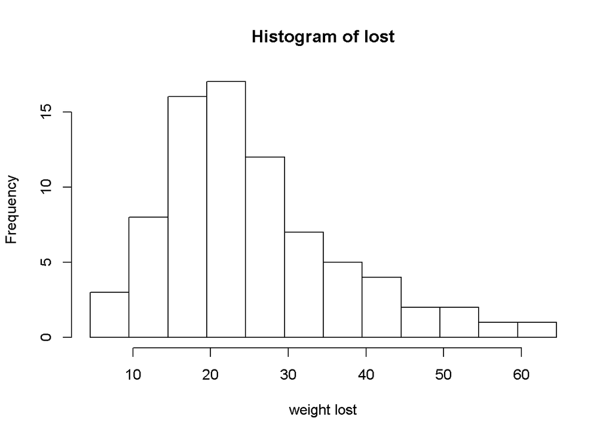

```r
hist(lost,
     breaks=breaks,
     xlim=range(breaks),
     xlab = "weight lost")
```

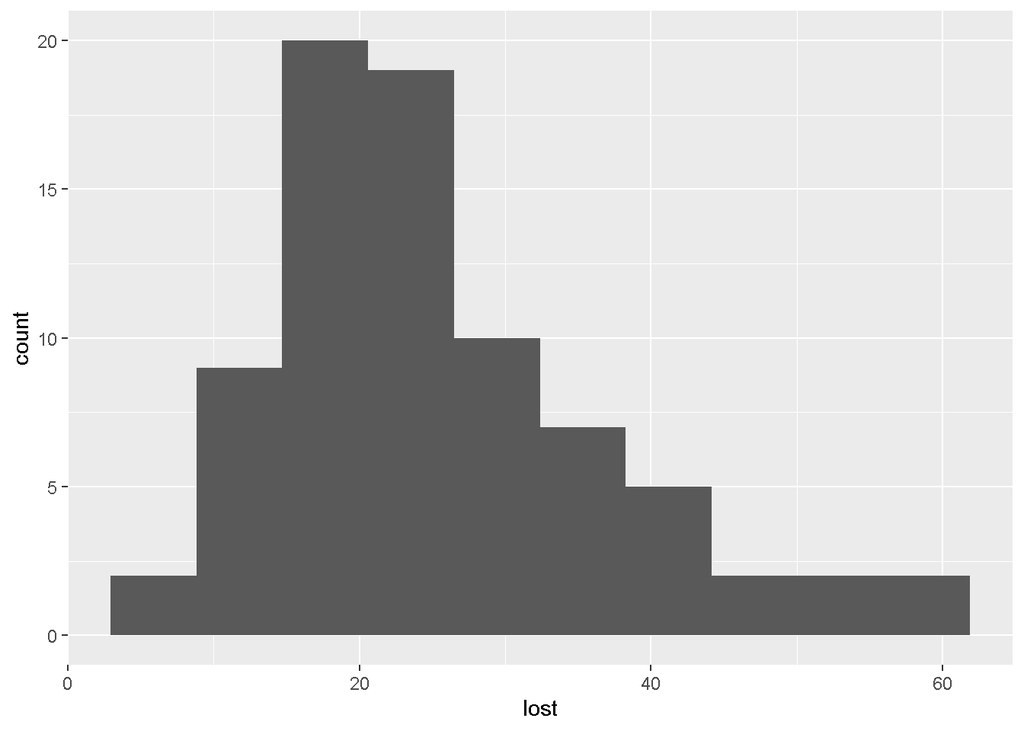

```r
ggplot(data.frame(lost),aes(lost))+
  geom_histogram(bins=10)
```

3. Is the distribution skewed or symmetrical? If it is skewed, is it skewed positively or negatively?

Skewed positively

4. Construct a stem and leaf diagram with the last digit being a leaf and the first digit a stem. Repeat stem values twice.

```r
stem(lost,1)
```

```
##
##   The decimal point is 1 digit(s) to the right of the |
##
##   0 | 789
##   1 | 001233445556666677788899
##   2 | 00001112223333444556666788889
##   3 | 011234455679
##   4 | 123368
##   5 | 237
##   6 | 0
```

```r
stem(lost,2)
```

```
##
##   The decimal point is 1 digit(s) to the right of the |
##
##   0 | 789
##   1 | 00123344
##   1 | 5556666677788899
##   2 | 00001112223333444
##   2 | 556666788889
##   3 | 0112344
##   3 | 55679
##   4 | 1233
##   4 | 68
##   5 | 23
##   5 | 7
##   6 | 0
```

5. Which diagram do you like better, the histogram of part b or the stem and leaf diagram of part d? Explain.

Stem and leaf diagram, 整數容易參考

## Ex3-15

A small eastern college uses the grading system of 0–4.0, with 4.0 being the highest possible grade.The scores shown here are the grade point averages of the students currently enrolled as psychology majors at the college.

| 2.7 1.9 1.0 3.3 1.3 1.8 2.6 3.7 |
| --- |
| 3.1 2.2 3.0 3.4 3.1 2.2 1.9 3.1 |
| 3.4 3.0 3.5 3.0 2.4 3.0 3.4 2.4 |
| 2.4 3.2 3.3 2.7 3.5 3.2 3.1 3.3 |
| 2.1 1.5 2.7 2.4 3.4 3.3 3.0 3.8 |
| 1.4 2.6 2.9 2.1 2.6 1.5 2.8 2.3 |
| 3.3 3.1 1.6 2.8 2.3 2.8 3.2 2.8 |
| 2.8 3.8 1.4 1.9 3.3 2.9 2.0 3.2 |

1. Construct a frequency distribution of grouped scores with approximately 10 intervals.

```r
grade <- c(2.7,1.9,1.0,3.3,1.3,1.8,2.6,3.7,
3.1,2.2,3.0,3.4,3.1,2.2,1.9,3.1,
3.4,3.0,3.5,3.0,2.4,3.0,3.4,2.4,
2.4,3.2,3.3,2.7,3.5,3.2,3.1,3.3,
2.1,1.5,2.7,2.4,3.4,3.3,3.0,3.8,
1.4,2.6,2.9,2.1,2.6,1.5,2.8,2.3,
3.3,3.1,1.6,2.8,2.3,2.8,3.2,2.8,
2.8,3.8,1.4,1.9,3.3,2.9,2.0,3.2)
range_grade <- range(grade)
width <- round( diff(range_grade)/10,1)
Complement <- width-(diff(range_grade) %% width)
breaks <- seq(range_grade[1]-Complement*0.5,
              range_grade[2]+Complement*0.5,
              by=width)
class_interval <- cut(grade,
                      breaks=breaks,
                      ordered_result=T,
                      right = T,
                      include.lowest = T)
Grade <- class_interval %>%
  table() %>%
  as.data.frame()

names(Grade) <- c("Real Limits","f")
Grade <- Grade[nrow(Grade):1,]
```

2. Construct a histogram of the frequency distribution constructed in part a.

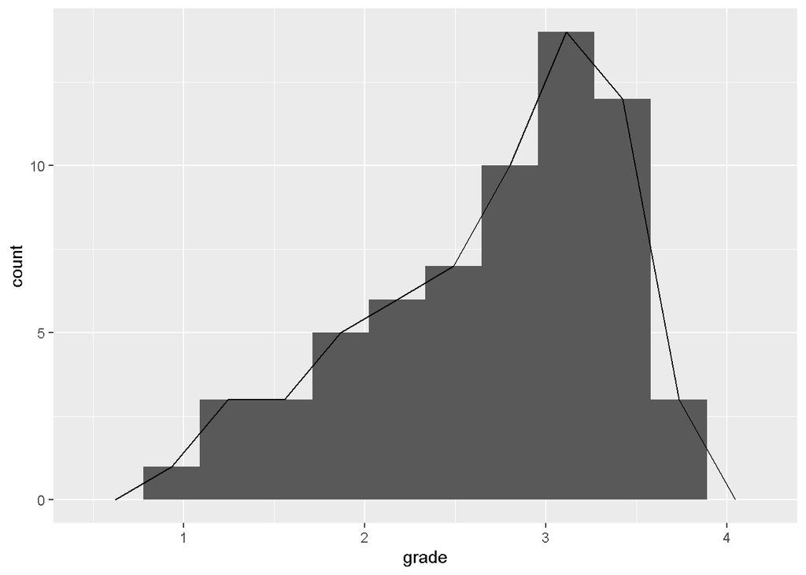

```r
ggplot(data.frame(grade),aes(grade))+
  geom_histogram(bins=10)+
  geom_freqpoly(bins=10)
```

3. Is the distribution skewed or symmetrical? If skewed, is it skewed positively or negatively?

Skewed negatively

4. Construct a stem and leaf diagram with the last digit being a leaf and the first digit a stem. Repeat stem values five times.

```r
stem(grade,1)
```

```
##
##   The decimal point is at the |
##
##   1 | 0344
##   1 | 5568999
##   2 | 01122334444
##   2 | 6667778888899
##   3 | 000001111122223333334444
##   3 | 55788
```

```r
stem(grade,5)
```

```
##
##   The decimal point is 1 digit(s) to the left of the |
##
##   10 | 0
##   11 |
##   12 |
##   13 | 0
##   14 | 00
##   15 | 00
##   16 | 0
##   17 |
##   18 | 0
##   19 | 000
##   20 | 0
##   21 | 00
```

[output cut: 17 more lines]

5. Which diagram do you like better, the histogram of part b or the stem and leaf diagram of part d? Explain.

Histogram, easy to decide.

## Ex3-20

The psychology department of a large university maintains its own vivarium of rats for research purposes. A recent sampling of 50 rats from the vivarium revealed the following rat weights:

| 320 282 341 324 340 302 336 265 313 317 |
| --- |
| 310 335 353 318 296 309 308 310 277 288 |
| 314 298 315 360 275 315 297 330 296 274 |
| 250 274 318 287 284 267 292 348 302 297 |
| 270 263 269 292 298 343 284 352 345 325 |

1. Construct a frequency distribution of grouped scores with approximately 11 intervals.

```r
rat <- c(320,282,341,324,340,302,336,265,313,317,
310,335,353,318,296,309,308,310,277,288,
314,298,315,360,275,315,297,330,296,274,
250,274,318,287,284,267,292,348,302,297,
270,263,269,292,298,343,284,352,345,325)

range_rat <- range(rat)
width <- round( diff(range_rat)/11 )
Complement <- width-(diff(range_rat) %% width)
breaks <- seq(range_rat[1]-0.5*Complement,
              range_rat[2]+0.5*Complement,
              by=width)
class_interval <- cut(rat,
                      breaks=breaks,
                      ordered_result=T,
                      right = T,
                      include.lowest = T)
rw <- class_interval %>%
  table() %>%
  as.data.frame()
rw[,3] <-
  paste0( head(ceiling(breaks),-1) ,
          "-",
          tail(floor(breaks),-1) )
rw <-rw[,c(3,1,2)]

names(rw) <- c("Class Interval","Real Limits","f")
rw <- rw[nrow(lw):1,]
knitr::kable(rw)
```

|  | Class Interval | Real Limits | f |
| --- | --- | --- | --- |
| 12 | 355-365 | (355,365] | 1 |
| 11 | 345-355 | (345,355] | 3 |
| 10 | 335-345 | (335,345] | 5 |
| 9 | 325-335 | (325,335] | 2 |
| 8 | 315-325 | (315,325] | 6 |
| 7 | 305-315 | (305,315] | 8 |
| 6 | 295-305 | (295,305] | 8 |
| 5 | 285-295 | (285,295] | 4 |
| 4 | 275-285 | (275,285] | 4 |
| 3 | 265-275 | (265,275] | 6 |
| 2 | 255-265 | (255,265] | 2 |
| 1 | 245-255 | [245,255] | 1 |

2. Construct a histogram of the frequency distribution constructed in part a.

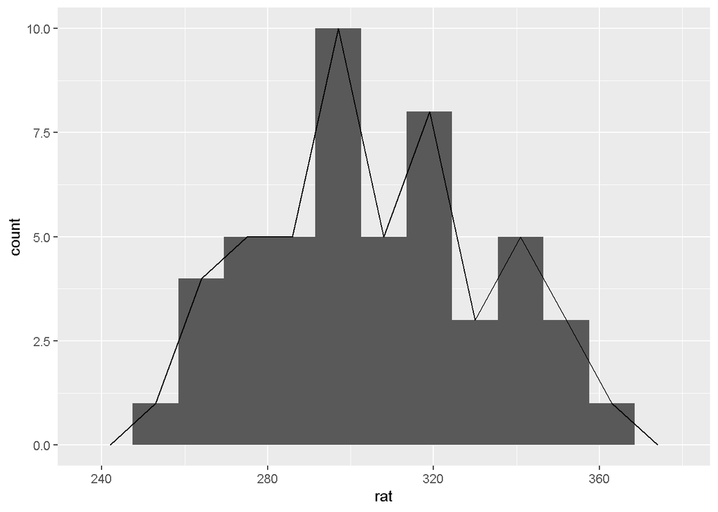

```r
ggplot(data.frame(rat),aes(rat))+
  geom_histogram(bins=11)+
  geom_freqpoly(bins=11)
```

3. Is the distribution symmetrical or skewed?

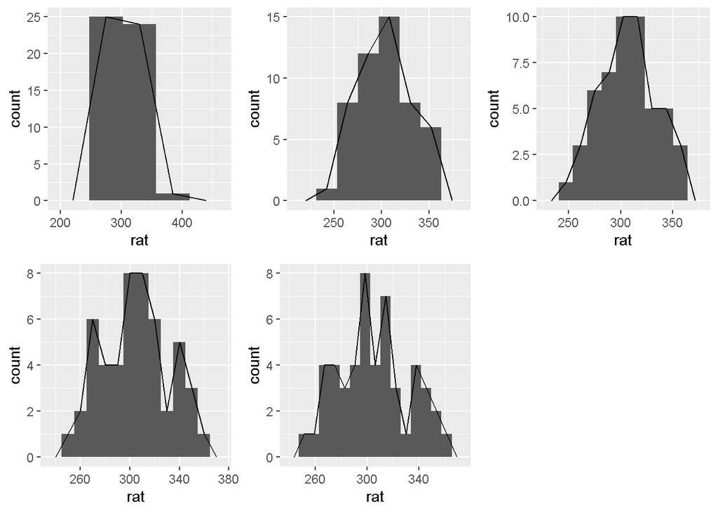

```r
library(purrr)
plot_frequency2 <- function(x){
  ggplot(data.frame(rat),aes(rat))+
  geom_histogram(bins=x)+
  geom_freqpoly(bins=x)
}
all_plots <- map(seq(3,15,3), plot_frequency2)
cowplot::plot_grid(plotlist = all_plots)
```

4. Construct a stem and leaf diagram with the last digit being a leaf and the first two digits a stem. Do not repeat stem values.

```r
stem(rat,1)
```

```
##
##   The decimal point is 1 digit(s) to the right of the |
##
##   24 | 0
##   26 | 357904457
##   28 | 2447822667788
##   30 | 2289003455788
##   32 | 045056
##   34 | 0135823
##   36 | 0
```

5. Which diagram do you like better, the histogram or the stem and leaf diagram? Why?

Stem and leaf diagram, 接近對稱看數字較清楚